# Chapter 5 (video 4)

2022-10-06

Load packages.

```r
library(tidyverse)
library(rethinking)
library(tidybayes)
library(tidybayes.rethinking)
library(ggthemes)
theme_set(theme_pander())
```

## Lecture 4

Data prep.

```r
data(Howell1)
d <- Howell1 |> filter(age >= 18)
d2 <- d |>
  rename(W = weight,
         H = height,
         A = age,
         S = male) |>
  mutate(S = as.integer(S+1))
```

Formula for estimating “causal system.”

```r
Hbar <- mean(d2$H)

flist <-
  alist(

  # weight model
    W ~ dnorm(mu, sigma),
    mu <- alpha[S] + beta[S]*(H-Hbar),
    alpha[S] ~ dnorm(45, 20),
    beta[S] ~ dlnorm(0, 1),
    sigma ~ dunif(0, 30),

  # height model
    H ~ dnorm(nu, tau),
    nu <- gamma[S],
    gamma[S] ~ dnorm(155, 30),
    tau ~ dunif(0, 30)

  )

fit <- quap(flist,
            data = d2)
```

Posterior summary

```r
precis(fit, depth = 2) # need depth = 2 when you have "vector" parameters like index variables
```

```
##                 mean         sd        5.5%       94.5%
## alpha[1]  45.1387669 0.43728216  44.4399055  45.8376282
## alpha[2]  45.0624841 0.45610243  44.3335443  45.7914239
## beta[1]    0.6539891 0.06085140   0.5567368   0.7512414
## beta[2]    0.6123199 0.05482592   0.5246975   0.6999424
## sigma      4.2279539 0.15934903   3.9732834   4.4826245
## gamma[1] 149.5145077 0.40372245 148.8692812 150.1597341
## gamma[2] 160.3573704 0.42979018 159.6704826 161.0442581
## tau        5.5213214 0.20809259   5.1887492   5.8538935
```

Get 10,000 draws from the posterior.

```r
pdraws <- tidy_draws(fit, n = 1e4) |>
  janitor::clean_names() |>    # fixes weird backticks and brackets
  select(-chain, -iteration)   # drops MCMC things we don't need

head(pdraws)
```

```
## # A tibble: 6 × 9
##    draw alpha_1 alpha_2 beta_1 beta_2 sigma gamma_1 gamma_2   tau
##   <int>   <dbl>   <dbl>  <dbl>  <dbl> <dbl>   <dbl>   <dbl> <dbl>
## 1     1    44.9    45.5  0.685  0.537  4.00    149.    160.  5.71
## 2     2    44.8    44.7  0.612  0.617  4.31    149.    160.  5.67
## 3     3    44.9    45.9  0.609  0.541  4.31    149.    160.  5.76
## 4     4    45.1    45.0  0.695  0.667  4.44    149.    160.  5.49
## 5     5    45.4    45.3  0.779  0.563  4.33    149.    160.  5.23
## 6     6    44.3    45.3  0.594  0.610  4.35    149.    161.  5.34
```

Now we can use this full posterior to make inferences about parameters and parameter differences.

For example, we might ask: what is the difference in the height -> weight slope between males (sex = 2) and females (sex = 1)?

```r
pdraws |>
  mutate(bdiff = beta_2 - beta_1) |>
  pull(bdiff) |>
  HPDI()
```

```
##       |0.89       0.89|
## -0.17685323  0.08443576
```

This is the 89% confidence interval of the difference in kg/cm between males and females.

Or we could estimate the total effect of sex on the height difference.

```r
pdraws |>
  mutate(gdiff = gamma_2 - gamma_1) |>
  pull(gdiff) |>
  HPDI()
```

```
##     |0.89     0.89|
##  9.957736 11.824936
```

This is the total sex-caused difference in height in cm. We could also plot it.

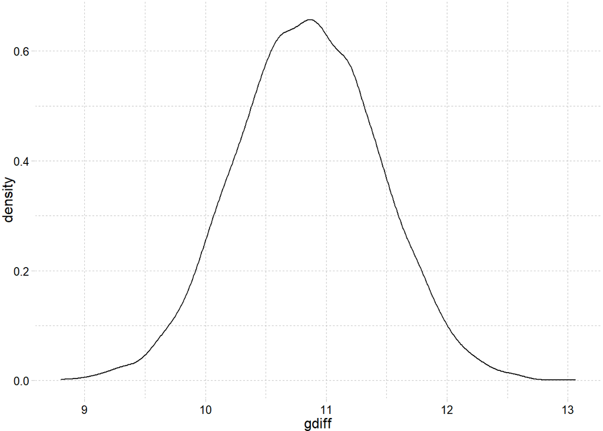

```r
pdraws |>
  mutate(gdiff = gamma_2 - gamma_1) |>

ggplot(aes(x = gdiff)) +
  geom_density()
```

Now RM wants to do an intervention where he calculates the intervention effect of changing natal sex (around 46:15 on the video). His code looks monstrous to me but this is what I think I’m seeing.

We want to know what would happen if we changed “female” to “male”. We need to calculate both the S -> W path and the S -> H -> W path.

We need to calculate two new simulated variables:

1. The data distribution for an average female implied by the model
2. The data distribution for an average male implied by the model

Then:

3. Take the difference between them.

We need to incorporate FIVE kinds of uncertainty in each of (1) and (2):

- uncertainty about each sex’s average height (with no other variables; i.e., uncertainty about gamma)
- uncertainty about the location of a *particular height* conditional on that average (tau)
- uncertainty about each sex’s average weight at the average height (alpha)
- uncertainty about the relationship between height and weight (uncertainty about beta)
- uncertainty about a *particular weight* conditional on the above (sigma)

```r
hbar <- mean(d2$H)

pdraws <- pdraws |>
  mutate(m_height = rnorm(nrow(pdraws), gamma_2, tau),
         f_height = rnorm(nrow(pdraws), gamma_1, tau),
         m_weight = rnorm(nrow(pdraws), alpha_2 + beta_2 * (m_height - hbar), sigma),
         f_weight = rnorm(nrow(pdraws), alpha_1 + beta_1 * (f_height - hbar), sigma),
         do_s = m_weight - f_weight)
```

We can plot the effect altering birth sex would have on weight in kg.

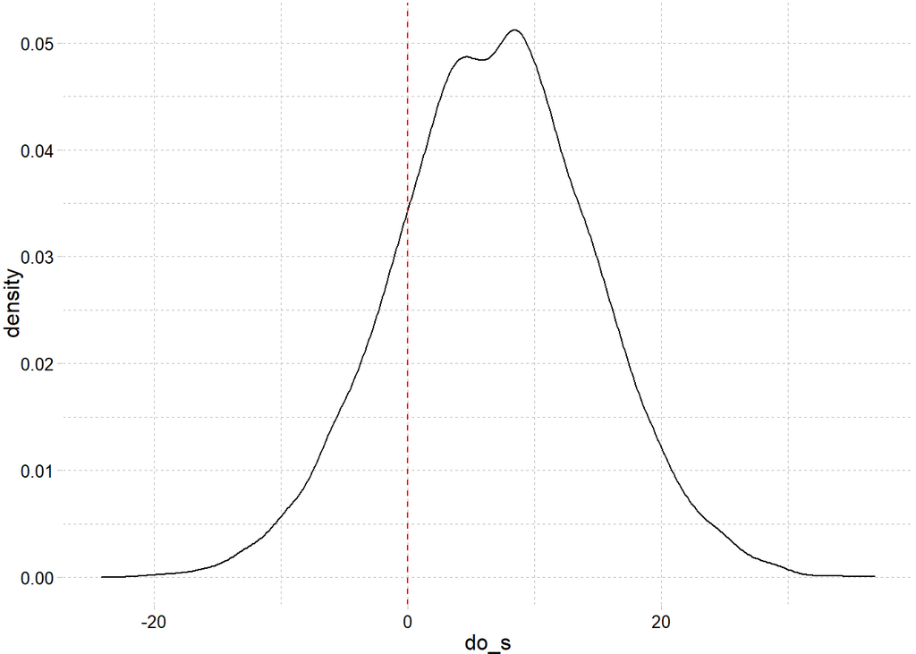

```r
data_sim_plot <-
  ggplot(pdraws,
         aes( x = do_s)) +
  geom_density() +
  geom_vline(xintercept = 0,
             color = "red",
             linetype = "dashed")

data_sim_plot
```

```r
mean(pdraws$do_s > 0)
```

```
## [1] 0.8089
```

I could do all of the above getting rid of the “residual” variance. There are easier ways, but why not this?

```r
hbar <- mean(d2$H)

pdraws2 <- pdraws |>
  mutate(m_height = rnorm(nrow(pdraws), gamma_2, 0),
         f_height = rnorm(nrow(pdraws), gamma_1, 0),
         m_weight = rnorm(nrow(pdraws), alpha_2 + beta_2 * (m_height - hbar), 0),
         f_weight = rnorm(nrow(pdraws), alpha_1 + beta_1 * (f_height - hbar), 0),
         do_s = m_weight - f_weight)
```

Now plot.

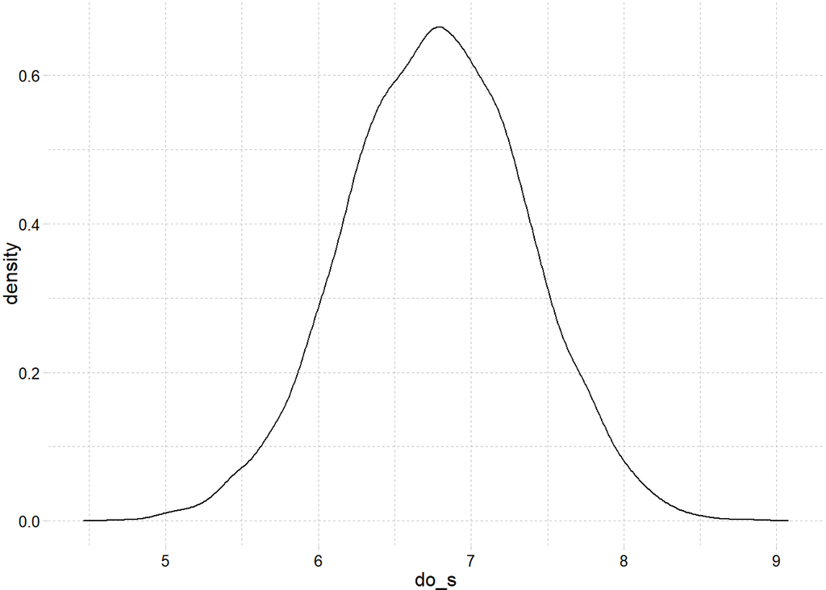

```r
par_sim_plot <-
ggplot(pdraws2,
       aes( x = do_s)) +
  geom_density()

par_sim_plot
```

Visualize both on top of each other.

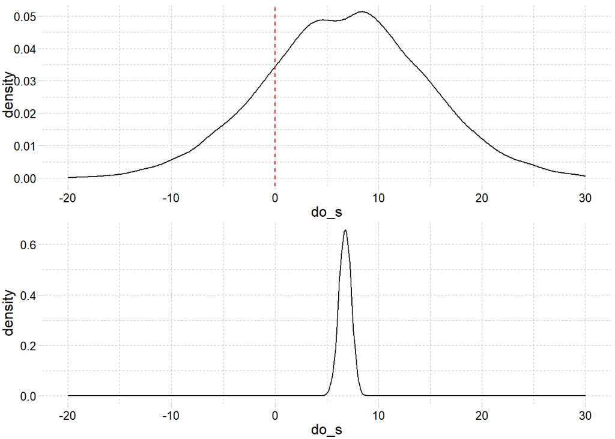

```r
library(patchwork)
p1 <- data_sim_plot + scale_x_continuous(limits = c(-20, 30))
p2 <- par_sim_plot + scale_x_continuous(limits = c(-20, 30))

p1/p2
```

## Lecture 5

Data prep.

```r
data("WaffleDivorce")
d <- WaffleDivorce |>
  select(Loc, Divorce, Marriage, MedianAgeMarriage, South) |>
  rename(state = Loc,
         D = Divorce,
         M = Marriage,
         A = MedianAgeMarriage,
         S = South) |>
  mutate(across(c(D,M,A),
                ~ (.x - mean(.x)) / sd(.x)))
```

Do model.

```r
flist <-
  alist(
    D ~ dnorm(mu, sigma),
    mu <- a + bM*M + bA*A,
    a ~ dnorm(0, .2),
    bM ~ dnorm(0, .5),
    bA ~ dnorm(0, .5),
    sigma ~ dexp(1)
  )

fit <- quap(flist,
            data = d)
```

Look at the posterior estimates.

```r
precis(fit)
```

```
##                mean         sd       5.5%      94.5%
## a      1.091905e-05 0.09707659 -0.1551362  0.1551581
## bM    -6.547579e-02 0.15077312 -0.3064404  0.1754888
## bA    -6.136151e-01 0.15098323 -0.8549155 -0.3723148
## sigma  7.851239e-01 0.07784476  0.6607129  0.9095348
```

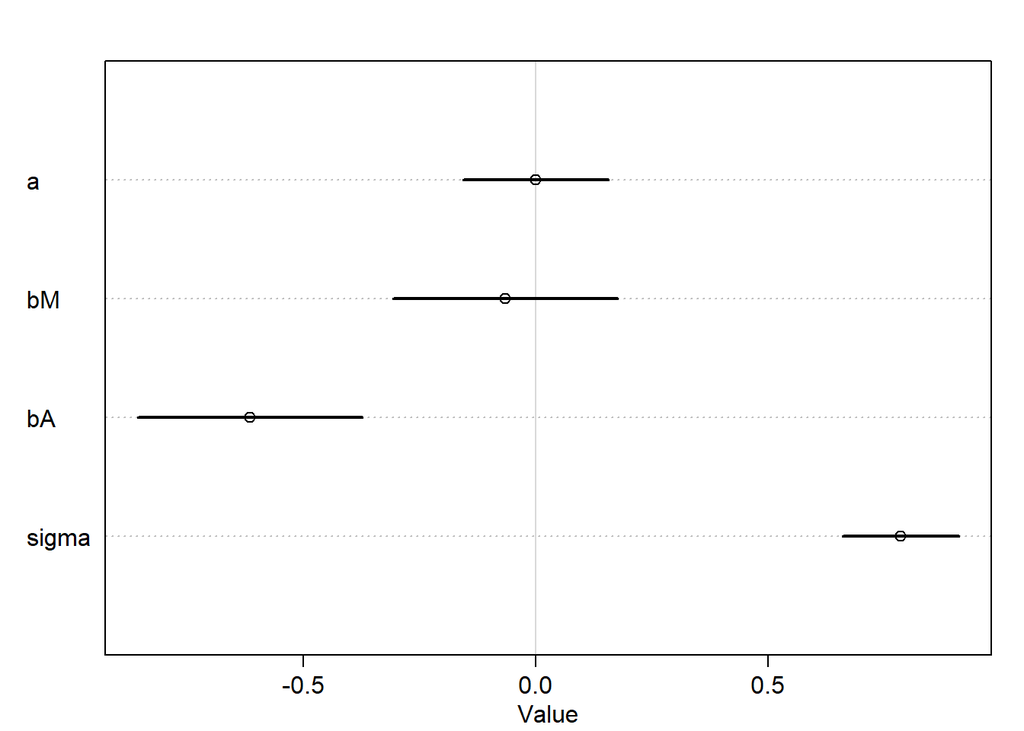

```r
precis(fit) |> plot()
```

Let’s try tidy.

```r
post <- tidy_draws(fit, n = 1e4) |>
  select(a:sigma)

head(post)
```

```
## # A tibble: 6 × 4
##         a      bM     bA sigma
##     <dbl>   <dbl>  <dbl> <dbl>
## 1  0.108   0.163  -0.389 0.897
## 2 -0.0309 -0.297  -0.801 0.887
## 3  0.0170  0.0115 -0.668 0.714
## 4  0.184  -0.409  -0.788 0.848
## 5  0.134   0.0843 -0.709 0.820
## 6 -0.0252 -0.0277 -0.609 0.975
```

Plotting prep.

```r
longpost <- post |>
  pivot_longer(everything(),
               names_to = "term",
               values_to = "values")

head(longpost, 8)
```

```
## # A tibble: 8 × 2
##   term   values
##   <chr>   <dbl>
## 1 a      0.108
## 2 bM     0.163
## 3 bA    -0.389
## 4 sigma  0.897
## 5 a     -0.0309
## 6 bM    -0.297
## 7 bA    -0.801
## 8 sigma  0.887
```

Plotting.

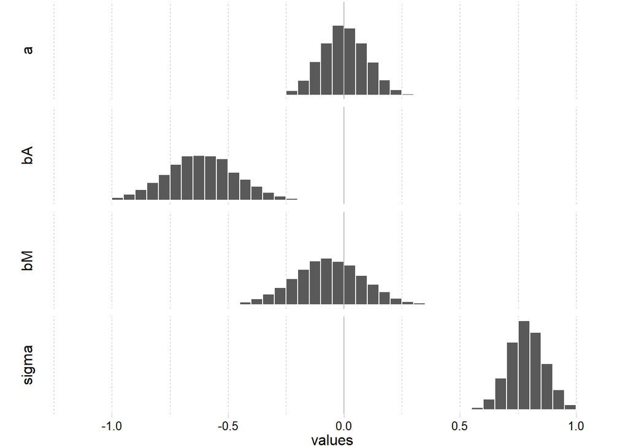

```r
ggplot(longpost,
       aes(x = values)) +
  geom_histogram(color = "white",
                 binwidth = .05,
                 boundary = 0) +
  facet_grid(rows = vars(term),
             switch = "y") +
  geom_vline(xintercept = 0,
             color = "gray") +
  scale_y_continuous(breaks = NULL) +
  labs(y = "")
```

Another way.

```r
postsum <- longpost |>
  group_by(term) |>
  summarize(mean = mean(values),
            lb = quantile(values, .055),
            ub = quantile(values, .945))
postsum
```

```
## # A tibble: 4 × 4
##   term       mean     lb     ub
##   <chr>     <dbl>  <dbl>  <dbl>
## 1 a      0.000901 -0.153  0.157
## 2 bA    -0.614    -0.857 -0.372
## 3 bM    -0.0663   -0.309  0.175
## 4 sigma  0.787     0.663  0.911
```

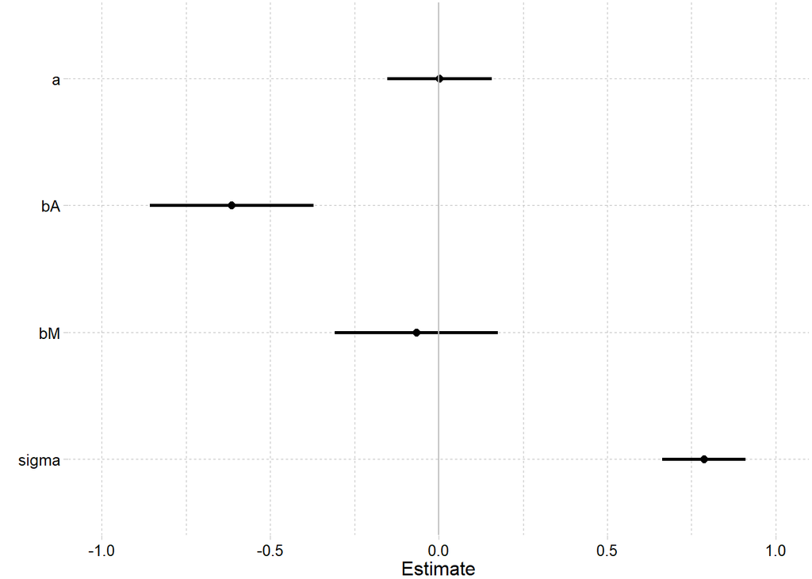

```r
ggplot(postsum,
       aes(y = reorder(term, c(4,3,2,1)),
           x = mean,
           xmin = lb,
           xmax = ub)) +
  geom_point(size = 2) +
  geom_linerange(size = 1) +
  geom_vline(xintercept = 0,
             color = "gray") +
  xlim(-1,1) +
  labs(x = "Estimate",
       y = "")
```

## Additional stuff

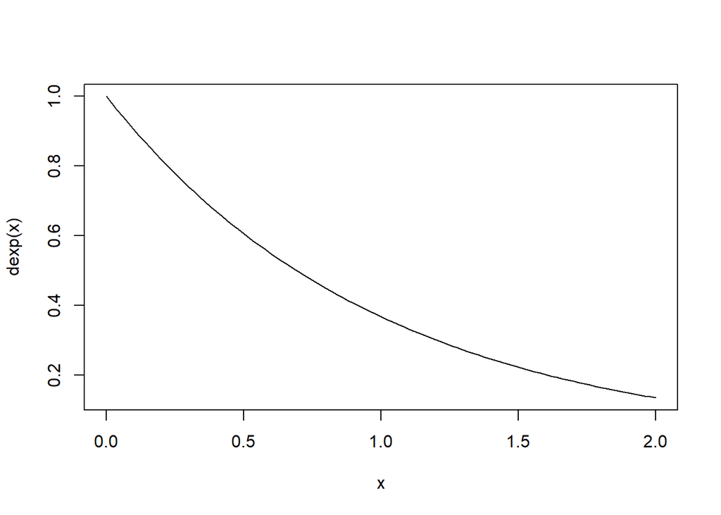

```r
curve(dexp(x), from = 0, to = 2)
```

## Fake data

```r
fakedata <- tibble(
  A = rnorm(1e4, 0, 1),
  M = rnorm(1e4, A*-.3, 1),
  mu = A,
  D = rnorm(1e4, mu, 1)
)

fakefit <- quap(
  flist,
  data = fakedata
)

precis(fakefit)
```

```
##               mean          sd        5.5%      94.5%
## a      0.000518803 0.009945396 -0.01537586 0.01641347
## bM    -0.008529223 0.009953073 -0.02443616 0.00737771
## bA     1.009160765 0.010388233  0.99255836 1.02576317
## sigma  0.995603972 0.007039603  0.98435333 1.00685462
```